# RethinkingLecture3_hw

Anita To

4/26/2019

Lecture: Why does µi have a sub i? (Refer to lecture slides) µi depends on β*xi. So it is kind of like a mean for that particular individual/sample that has some normal disbribution around xi (predictor), therefore µi depends on the individual or sample. Which will all be used to estimate our observed value yi.

# Chapter 4 - Easy Problems

## 4E1.

In the model definition below, which line is the likelihood? yi ∼ Normal(μ, σ) μ ∼ Normal(0, 10) σ ∼ Uniform(0, 10)

Answer: yi is the likelihood

## 4E2.

In the model definition just above, how many parameters are in the posterior distribution?

Answer: Two parameters are in the posterior distribution (µ and σ).

## 4E3.

Using the model definition above, write down the appropriate form of Bayes’ theorem that includes the proper likelihood and priors.

## 4E4.

In the model definition below, which line is the linear model? yi ∼ Normal(μ, σ) μi =α+βxi α ∼ Normal(0, 10) β ∼ Normal(0, 1) σ ∼ Uniform(0, 10)

Answer: µi is the linear model.

## 4E5.

In the model definition just above, how many parameters are in the posterior distribution?

Answer: Three – α, β, and σ.

# Chapter 4 - Medium Problems

## 4M1.

For the model definition below, simulate observed heights from the prior (not the posterior). yi ∼ Normal(μ, σ) μ ∼ Normal(0, 10) σ ∼ Uniform(0, 10)

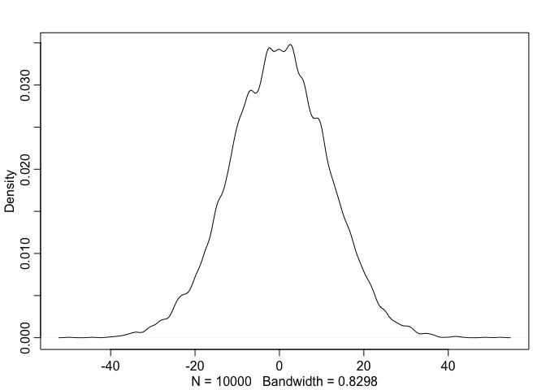

```r
knitr::opts_chunk$set(echo = TRUE)

library(rethinking)
sample_mu <- rnorm(1e4, 0, 10)
sample_sigma <- runif(1e4, 0, 10)
prior_y <- rnorm(1e4, sample_mu, sample_sigma)
dens(prior_y)
```

## 4M2.

Translate the model just above into a quap formula.

```r
knitr::opts_chunk$set(echo = TRUE)

flist <- alist(
    y ~ dnorm( mu , sigma ),
    mu <- dnorm(0, 10),
    sigma ~ dunif(0, 10)
)
```

## 4M3.

Translate the quap model formula below into a mathematical model definition. flist <- alist( y ~ dnorm( mu , sigma ), mu <- a + b*x, a ~ dnorm( 0 , 50 ), b ~ dunif( 0 , 10 ), sigma ~ dunif( 0 , 50 ) )

Answer: (“mathematical equations/latex in R Markdown” can recapitulate real math equation fonts)
$$y_i \sim Normal(µ, σ) \\
µ \sim \alpha + \beta x_i \\
α \sim Normal(0, 50) \\
β \sim Uniform(0, 10) \\
σ \sim Uniform(0, 50)$$